# Grupo5_Discriminacion

# Descripción de la Base de Datos:

La presente base de datos forma parte de una encuesta realizada por la INEI sobre la situación de la población migrante de Venezuela en el Perú.Por motivos de la investigación que llevaremos a cabo, se ha seleccionado tan solamente unos cuantos módulos. Debido a que nuestro tema central es la discriminación que perciben los migrantes, hemos seleccionado el módulo 11. Asimismo, hemos agregado este dos módulos adicionales que nos permitirán complementar la información. De esta manera, con ayuda del módulo 2 (Datos generales) y el módulo 6 (empleo), hemos creadi una sola base de datos que nos permita afinar nuestra perspectiva de trabajo.

La base de datos que hemos creado cuenta con 152 variables que permiten abarcar la descripción 8836 casos. Algunas de las variables, al formar de una sola encuesta, dependen de otras para que pueda confirmarse. Al revisar la encuesta, por ejemplo, nos percatamos que algunas preguntas nos dan indicaciones de obviar unas o pasar a otras directamente según la respuesta. Otra particularidad esta base de datos es que no encontramos una dimensión temporal debido a que el proceso de encuesta se realizo en un solo mes. Por este motivo, hemos obviado las variables que señalaban las fechas en la base de datos original.

# Descripcion del proyecto

## Planteamiento del Problema:

América Latina está enfrentando el impacto del nuevo flujo migratorio protagonizado por los ciudadanos venezolanos debido a la crisis económica, social y política que afecta a su país. Esta ola migratoria ha traído desafíos para los Estados de América Latina en su capacidad de dar una respuesta pronta y eficiente en atender las necesidades básicas, no solo de asistencia sino de protección. La intensificación y celeridad de la afluencia migratoria de venezolanos debería comprender políticas de integración para evitar los peligros de la xenofobia y la vulnerabilidad de sus derechos fundamentales. Frente a ello, es importante identificar la percepción del migrante venezolano en nuestro país frente a la problemática de discriminación que impacta en su cotidianeidad.

## Pregunta de Investigación y objetivos:

1. ¿Cómo ha impactado la discriminación en la vida de los migrantes venezolanos en el Perú?
2. Objetivos:
   - Objetivo principal:

     Medir el impacto de la discriminación en la vida de los migrantes venezolanos en el Perú
   - Objetivos secundarios:
     - Describir el perfil del migrante venezolano e identificar las características de posibles situaciones de discriminación.
     - Analizar la percepción del migrante venezolano frente a la problemática de discriminación

# Análisis exploratorio de las principales variables a estudiar

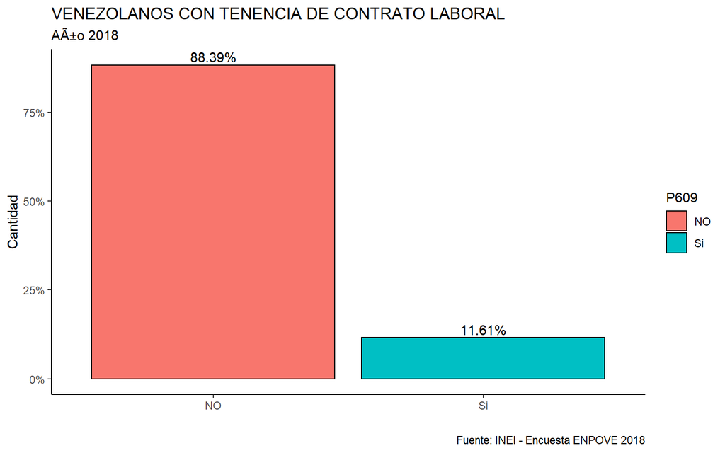

## VARIABLE: P611

## **¿CUÁNTAS HORAS TRABAJÓ, EN SU OCUPACIÓN PRINCIPAL, Y OCUPACIÓN/ES SECUNDARIA/S?**

### Esta variable captar la cantidad de horas efectivamente laboradas en las actividades principales y secundarias por los/as ocupados/as durante el perÃodo de referencia. Se incluyen las horas extraordinarias y se excluyen los permisos, licencias, tiempo de refrigerio, tiempo de traslado del domicilio al centro de trabajo y viceversa, etc.

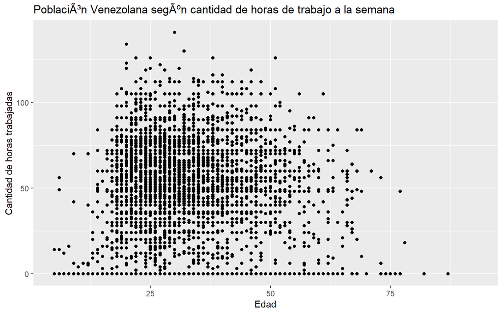

## VARIABLE: ingtot

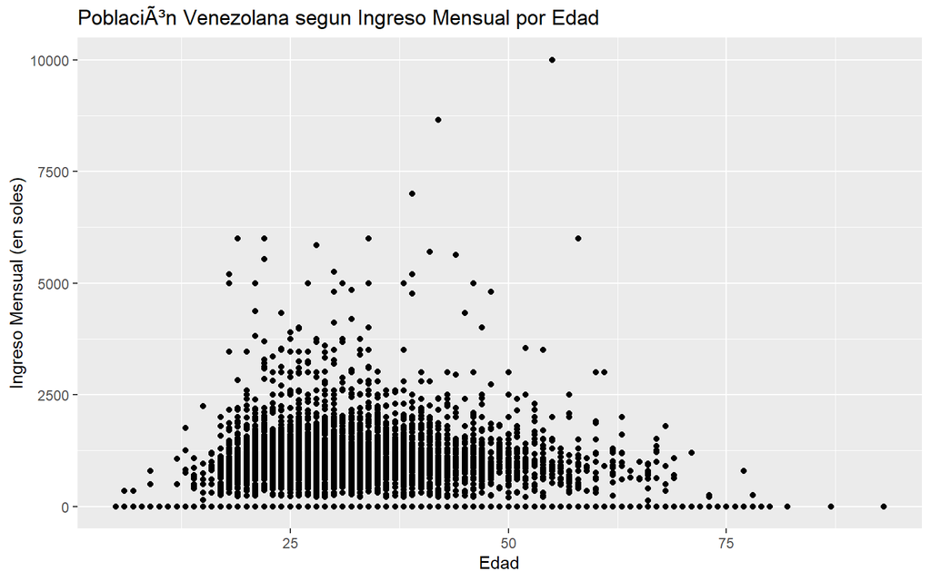

## VARIABLE: P624

## **¿CUÁNTAS SEMANAS HA ESTADO BUSCANDO TRABAJO, SIN INTERRUPCIONES?**

### Determinar el tiempo, en semanas, que los desocupados invierten en la búsqueda de un empleo y tener una idea general respecto a las características de desempleo, esto permitirá diseñar políticas más adecuadas al respecto.

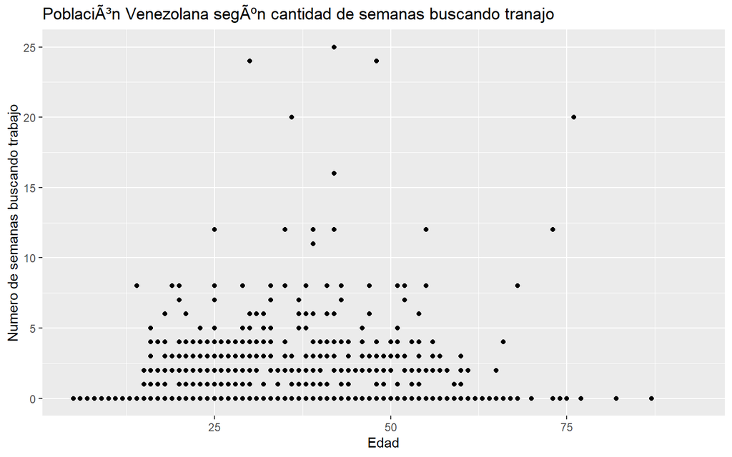

[figure not shown]